# Risk Factor Analysis

## Outcome Variable

**Outcome Variable:** pers_wast

## Predictor Variables

**Intervention Variable:** hdlvry

**Adjustment Set:**

- arm
- sex
- W_mage
- meducyrs
- feducyrs
- hhwealth_quart
- single
- W_nrooms
- brthmon
- W_parity
- impsan
- delta_W_mage
- delta_meducyrs
- delta_feducyrs
- delta_hhwealth_quart
- delta_single
- delta_W_nrooms
- delta_brthmon
- delta_W_parity
- delta_impsan

## Stratifying Variables

The analysis was stratified on these variable(s):

- agecat
- studyid
- country

## Data Summary

| agecat | studyid | country | hdlvry | pers_wast | n_cell | n |
| --- | --- | --- | --- | --- | --- | --- |
| 0-24 months | CMC-V-BCS-2002 | INDIA | 0 | 0 | 339 | 370 |
| 0-24 months | CMC-V-BCS-2002 | INDIA | 0 | 1 | 23 | 370 |
| 0-24 months | CMC-V-BCS-2002 | INDIA | 1 | 0 | 8 | 370 |
| 0-24 months | CMC-V-BCS-2002 | INDIA | 1 | 1 | 0 | 370 |
| 0-24 months | COHORTS | INDIA | 0 | 0 | 2249 | 3931 |
| 0-24 months | COHORTS | INDIA | 0 | 1 | 197 | 3931 |
| 0-24 months | COHORTS | INDIA | 1 | 0 | 1292 | 3931 |
| 0-24 months | COHORTS | INDIA | 1 | 1 | 193 | 3931 |
| 0-24 months | EE | PAKISTAN | 0 | 0 | 232 | 375 |
| 0-24 months | EE | PAKISTAN | 0 | 1 | 20 | 375 |
| 0-24 months | EE | PAKISTAN | 1 | 0 | 111 | 375 |
| 0-24 months | EE | PAKISTAN | 1 | 1 | 12 | 375 |
| 0-24 months | GMS-Nepal | NEPAL | 0 | 0 | 121 | 556 |
| 0-24 months | GMS-Nepal | NEPAL | 0 | 1 | 18 | 556 |
| 0-24 months | GMS-Nepal | NEPAL | 1 | 0 | 359 | 556 |
| 0-24 months | GMS-Nepal | NEPAL | 1 | 1 | 58 | 556 |
| 0-24 months | IRC | INDIA | 0 | 0 | 354 | 410 |
| 0-24 months | IRC | INDIA | 0 | 1 | 48 | 410 |
| 0-24 months | IRC | INDIA | 1 | 0 | 8 | 410 |
| 0-24 months | IRC | INDIA | 1 | 1 | 0 | 410 |
| 0-24 months | JiVitA-3 | BANGLADESH | 0 | 0 | 36 | 323 |
| 0-24 months | JiVitA-3 | BANGLADESH | 0 | 1 | 1 | 323 |
| 0-24 months | JiVitA-3 | BANGLADESH | 1 | 0 | 273 | 323 |
| 0-24 months | JiVitA-3 | BANGLADESH | 1 | 1 | 13 | 323 |
| 0-24 months | JiVitA-4 | BANGLADESH | 0 | 0 | 1077 | 4426 |
| 0-24 months | JiVitA-4 | BANGLADESH | 0 | 1 | 72 | 4426 |
| 0-24 months | JiVitA-4 | BANGLADESH | 1 | 0 | 2998 | 4426 |
| 0-24 months | JiVitA-4 | BANGLADESH | 1 | 1 | 279 | 4426 |
| 0-24 months | NIH-Crypto | BANGLADESH | 0 | 0 | 551 | 730 |
| 0-24 months | NIH-Crypto | BANGLADESH | 0 | 1 | 16 | 730 |
| 0-24 months | NIH-Crypto | BANGLADESH | 1 | 0 | 153 | 730 |
| 0-24 months | NIH-Crypto | BANGLADESH | 1 | 1 | 10 | 730 |
| 0-24 months | PROVIDE | BANGLADESH | 0 | 0 | 469 | 641 |
| 0-24 months | PROVIDE | BANGLADESH | 0 | 1 | 10 | 641 |
| 0-24 months | PROVIDE | BANGLADESH | 1 | 0 | 157 | 641 |
| 0-24 months | PROVIDE | BANGLADESH | 1 | 1 | 5 | 641 |
| 0-24 months | SAS-CompFeed | INDIA | 0 | 0 | 142 | 1116 |
| 0-24 months | SAS-CompFeed | INDIA | 0 | 1 | 9 | 1116 |
| 0-24 months | SAS-CompFeed | INDIA | 1 | 0 | 872 | 1116 |
| 0-24 months | SAS-CompFeed | INDIA | 1 | 1 | 93 | 1116 |
| 0-24 months | SAS-FoodSuppl | INDIA | 0 | 0 | 64 | 375 |
| 0-24 months | SAS-FoodSuppl | INDIA | 0 | 1 | 10 | 375 |
| 0-24 months | SAS-FoodSuppl | INDIA | 1 | 0 | 246 | 375 |
| 0-24 months | SAS-FoodSuppl | INDIA | 1 | 1 | 55 | 375 |
| 0-24 months | TanzaniaChild2 | TANZANIA, UNITED REPUBLIC OF | 0 | 0 | 1966 | 2056 |
| 0-24 months | TanzaniaChild2 | TANZANIA, UNITED REPUBLIC OF | 0 | 1 | 56 | 2056 |
| 0-24 months | TanzaniaChild2 | TANZANIA, UNITED REPUBLIC OF | 1 | 0 | 33 | 2056 |
| 0-24 months | TanzaniaChild2 | TANZANIA, UNITED REPUBLIC OF | 1 | 1 | 1 | 2056 |

The following strata were considered:

- agecat: 0-24 months, studyid: CMC-V-BCS-2002, country: INDIA
- agecat: 0-24 months, studyid: COHORTS, country: INDIA
- agecat: 0-24 months, studyid: EE, country: PAKISTAN
- agecat: 0-24 months, studyid: GMS-Nepal, country: NEPAL
- agecat: 0-24 months, studyid: IRC, country: INDIA
- agecat: 0-24 months, studyid: JiVitA-3, country: BANGLADESH
- agecat: 0-24 months, studyid: JiVitA-4, country: BANGLADESH
- agecat: 0-24 months, studyid: NIH-Crypto, country: BANGLADESH
- agecat: 0-24 months, studyid: PROVIDE, country: BANGLADESH
- agecat: 0-24 months, studyid: SAS-CompFeed, country: INDIA
- agecat: 0-24 months, studyid: SAS-FoodSuppl, country: INDIA
- agecat: 0-24 months, studyid: TanzaniaChild2, country: TANZANIA, UNITED REPUBLIC OF

### Dropped Strata

Some strata were dropped due to rare outcomes:

- agecat: 0-24 months, studyid: CMC-V-BCS-2002, country: INDIA
- agecat: 0-24 months, studyid: IRC, country: INDIA
- agecat: 0-24 months, studyid: JiVitA-3, country: BANGLADESH
- agecat: 0-24 months, studyid: TanzaniaChild2, country: TANZANIA, UNITED REPUBLIC OF

## Methods Detail

We're interested in the causal parameters $E[Y_a]$ for all values of $a \in \mathcal{A}$. These parameters represent the mean outcome if, possibly contrary to fact, we intervened to set all units to have $A=a$. Under the randomization and positivity assumptions, these are identified by the statistical parameters $\psi_a=E_W[E_{Y|A,W}(Y|A=a,W)]$. In addition, we're interested in the mean of $Y$, $E[Y]$ under no intervention (the observed mean). We will estimate these parameters by using SuperLearner to fit the relevant likelihood factors -- $E_{Y|A,W}(Y|A=a,W)$ and $p(A=a|W)$, and then updating our likelihood fit using a joint TMLE.

For unadjusted analyses ($W=\{\}$), initial likelihoods were estimated using Lrnr_glm to estimate the simple $E(Y|A)$ and Lrnr_mean to estimate $p(A)$. For adjusted analyses, a small library containing Lrnr_glmnet, Lrnr_xgboost, and Lrnr_mean was used.

Having estimated these parameters, we will then use the delta method to estimate relative risks and attributable risks relative to a prespecified baseline level of $A$.

# Results Detail

## Results Plots

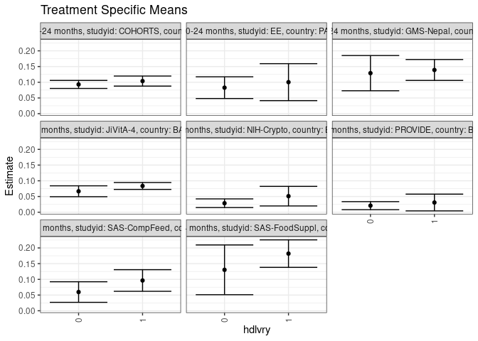

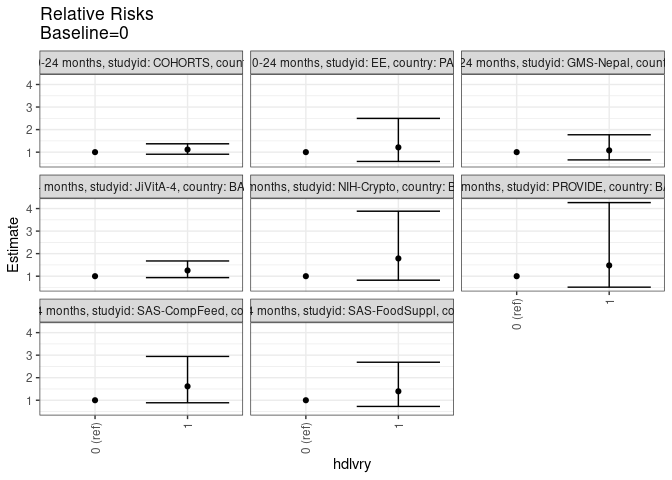

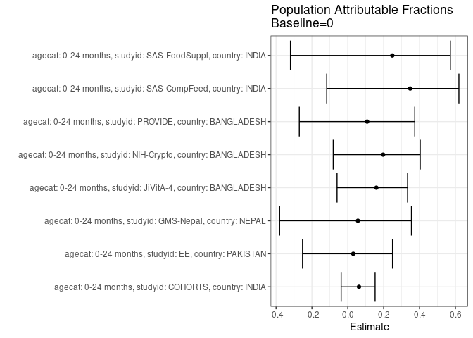

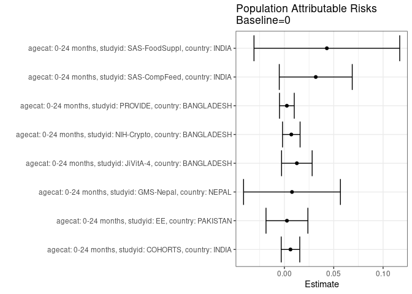

## Results Table

### Parameter: TSM

| agecat | studyid | country | intervention_level | baseline_level | estimate | ci_lower | ci_upper |
| --- | --- | --- | --- | --- | --- | --- | --- |
| 0-24 months | COHORTS | INDIA | 0 | NA | 0.0930280 | 0.0802434 | 0.1058126 |
| 0-24 months | COHORTS | INDIA | 1 | NA | 0.1037511 | 0.0877346 | 0.1197677 |
| 0-24 months | EE | PAKISTAN | 0 | NA | 0.0827371 | 0.0481440 | 0.1173302 |
| 0-24 months | EE | PAKISTAN | 1 | NA | 0.1002846 | 0.0414267 | 0.1591424 |
| 0-24 months | GMS-Nepal | NEPAL | 0 | NA | 0.1289803 | 0.0729026 | 0.1850580 |
| 0-24 months | GMS-Nepal | NEPAL | 1 | NA | 0.1390742 | 0.1058013 | 0.1723471 |
| 0-24 months | JiVitA-4 | BANGLADESH | 0 | NA | 0.0666649 | 0.0492848 | 0.0840450 |
| 0-24 months | JiVitA-4 | BANGLADESH | 1 | NA | 0.0835773 | 0.0725585 | 0.0945960 |
| 0-24 months | NIH-Crypto | BANGLADESH | 0 | NA | 0.0285962 | 0.0148126 | 0.0423798 |
| 0-24 months | NIH-Crypto | BANGLADESH | 1 | NA | 0.0511086 | 0.0199351 | 0.0822822 |
| 0-24 months | PROVIDE | BANGLADESH | 0 | NA | 0.0208768 | 0.0080633 | 0.0336904 |
| 0-24 months | PROVIDE | BANGLADESH | 1 | NA | 0.0308642 | 0.0042110 | 0.0575174 |
| 0-24 months | SAS-CompFeed | INDIA | 0 | NA | 0.0596026 | 0.0268592 | 0.0923461 |
| 0-24 months | SAS-CompFeed | INDIA | 1 | NA | 0.0963731 | 0.0619791 | 0.1307670 |
| 0-24 months | SAS-FoodSuppl | INDIA | 0 | NA | 0.1302979 | 0.0511154 | 0.2094805 |
| 0-24 months | SAS-FoodSuppl | INDIA | 1 | NA | 0.1819422 | 0.1381986 | 0.2256858 |

### Parameter: E(Y)

| agecat | studyid | country | intervention_level | baseline_level | estimate | ci_lower | ci_upper |
| --- | --- | --- | --- | --- | --- | --- | --- |
| 0-24 months | COHORTS | INDIA | NA | NA | 0.0992114 | 0.0898650 | 0.1085578 |
| 0-24 months | EE | PAKISTAN | NA | NA | 0.0853333 | 0.0570192 | 0.1136475 |
| 0-24 months | GMS-Nepal | NEPAL | NA | NA | 0.1366906 | 0.1081112 | 0.1652701 |
| 0-24 months | JiVitA-4 | BANGLADESH | NA | NA | 0.0793041 | 0.0701363 | 0.0884719 |
| 0-24 months | NIH-Crypto | BANGLADESH | NA | NA | 0.0356164 | 0.0221630 | 0.0490699 |
| 0-24 months | PROVIDE | BANGLADESH | NA | NA | 0.0234009 | 0.0116889 | 0.0351130 |
| 0-24 months | SAS-CompFeed | INDIA | NA | NA | 0.0913978 | 0.0593363 | 0.1234594 |
| 0-24 months | SAS-FoodSuppl | INDIA | NA | NA | 0.1733333 | 0.1349698 | 0.2116969 |

### Parameter: RR

| agecat | studyid | country | intervention_level | baseline_level | estimate | ci_lower | ci_upper |
| --- | --- | --- | --- | --- | --- | --- | --- |
| 0-24 months | COHORTS | INDIA | 0 | 0 | 1.000000 | 1.0000000 | 1.000000 |
| 0-24 months | COHORTS | INDIA | 1 | 0 | 1.115268 | 0.9078560 | 1.370067 |
| 0-24 months | EE | PAKISTAN | 0 | 0 | 1.000000 | 1.0000000 | 1.000000 |
| 0-24 months | EE | PAKISTAN | 1 | 0 | 1.212087 | 0.5883827 | 2.496938 |
| 0-24 months | GMS-Nepal | NEPAL | 0 | 0 | 1.000000 | 1.0000000 | 1.000000 |
| 0-24 months | GMS-Nepal | NEPAL | 1 | 0 | 1.078259 | 0.6563050 | 1.771497 |
| 0-24 months | JiVitA-4 | BANGLADESH | 0 | 0 | 1.000000 | 1.0000000 | 1.000000 |
| 0-24 months | JiVitA-4 | BANGLADESH | 1 | 0 | 1.253692 | 0.9380121 | 1.675612 |
| 0-24 months | NIH-Crypto | BANGLADESH | 0 | 0 | 1.000000 | 1.0000000 | 1.000000 |
| 0-24 months | NIH-Crypto | BANGLADESH | 1 | 0 | 1.787254 | 0.8225412 | 3.883427 |
| 0-24 months | PROVIDE | BANGLADESH | 0 | 0 | 1.000000 | 1.0000000 | 1.000000 |
| 0-24 months | PROVIDE | BANGLADESH | 1 | 0 | 1.478395 | 0.5124750 | 4.264895 |
| 0-24 months | SAS-CompFeed | INDIA | 0 | 0 | 1.000000 | 1.0000000 | 1.000000 |
| 0-24 months | SAS-CompFeed | INDIA | 1 | 0 | 1.616926 | 0.8882404 | 2.943402 |
| 0-24 months | SAS-FoodSuppl | INDIA | 0 | 0 | 1.000000 | 1.0000000 | 1.000000 |
| 0-24 months | SAS-FoodSuppl | INDIA | 1 | 0 | 1.396355 | 0.7258698 | 2.686167 |

### Parameter: PAR

| agecat | studyid | country | intervention_level | baseline_level | estimate | ci_lower | ci_upper |
| --- | --- | --- | --- | --- | --- | --- | --- |
| 0-24 months | COHORTS | INDIA | 0 | NA | 0.0061834 | -0.0032133 | 0.0155801 |
| 0-24 months | EE | PAKISTAN | 0 | NA | 0.0025962 | -0.0186031 | 0.0237956 |
| 0-24 months | GMS-Nepal | NEPAL | 0 | NA | 0.0077103 | -0.0413508 | 0.0567715 |
| 0-24 months | JiVitA-4 | BANGLADESH | 0 | NA | 0.0126392 | -0.0028622 | 0.0281407 |
| 0-24 months | NIH-Crypto | BANGLADESH | 0 | NA | 0.0070203 | -0.0018826 | 0.0159231 |
| 0-24 months | PROVIDE | BANGLADESH | 0 | NA | 0.0025241 | -0.0049575 | 0.0100057 |
| 0-24 months | SAS-CompFeed | INDIA | 0 | NA | 0.0317952 | -0.0051651 | 0.0687555 |
| 0-24 months | SAS-FoodSuppl | INDIA | 0 | NA | 0.0430354 | -0.0307752 | 0.1168460 |

### Parameter: PAF

| agecat | studyid | country | intervention_level | baseline_level | estimate | ci_lower | ci_upper |
| --- | --- | --- | --- | --- | --- | --- | --- |
| 0-24 months | COHORTS | INDIA | 0 | NA | 0.0623258 | -0.0370866 | 0.1522088 |
| 0-24 months | EE | PAKISTAN | 0 | NA | 0.0304247 | -0.2524074 | 0.2493846 |
| 0-24 months | GMS-Nepal | NEPAL | 0 | NA | 0.0564073 | -0.3801187 | 0.3548618 |
| 0-24 months | JiVitA-4 | BANGLADESH | 0 | NA | 0.1593765 | -0.0599596 | 0.3333257 |
| 0-24 months | NIH-Crypto | BANGLADESH | 0 | NA | 0.1971073 | -0.0812335 | 0.4037951 |
| 0-24 months | PROVIDE | BANGLADESH | 0 | NA | 0.1078636 | -0.2703716 | 0.3734846 |
| 0-24 months | SAS-CompFeed | INDIA | 0 | NA | 0.3478769 | -0.1175046 | 0.6194516 |
| 0-24 months | SAS-FoodSuppl | INDIA | 0 | NA | 0.2482812 | -0.3196921 | 0.5718083 |